# Neural Network For Regression, Overfit

Benoit and Sarat

Macquarie University

benoit.liquet-weiland@mq.edu.au

5 April 2023

# Contents

$\newcommand{\vect}[1]{\boldsymbol{#1}}$ $\newcommand{\transp}{^{\text{T}}}$ $\newcommand{\mat}[1]{\boldsymbol{\mathcal{#1}}}$ $\newcommand{\sign}{\text{sign}}$

This code samples are mainly from Chapter 3, Section 7 of [Deep Learning with R](https://www.manning.com/books/deep-learning-with-r).

# 1 The Boston Housing Price dataset

Aim: predict the median price of homes in a given Boston suburb in the mid-1970s, given a few data points about the suburb at the time, such as the crime rate, the local property tax rate, etc.

The dataset:

- 506 in total, split between 404 training samples and 102 test samples
- Each “feature” in the input data (e.g. the crime rate is a feature) has a different scale.

```r
library(keras)

dataset <- dataset_boston_housing()
c(c(train_data, train_targets), c(test_data, test_targets)) %<-% dataset
```

```r
str(train_data)
```

```
 num [1:404, 1:13] 1.2325 0.0218 4.8982 0.0396 3.6931 ...
```

```r
str(test_data)
```

```
 num [1:102, 1:13] 18.0846 0.1233 0.055 1.2735 0.0715 ...
```

The 13 features in the input data are as follow:

1. Per capita crime rate.
2. Proportion of residential land zoned for lots over 25,000 square feet.
3. Proportion of non-retail business acres per town.
4. Charles River dummy variable (= 1 if tract bounds river; 0 otherwise).
5. Nitric oxides concentration (parts per 10 million).
6. Average number of rooms per dwelling.
7. Proportion of owner-occupied units built prior to 1940.
8. Weighted distances to five Boston employment centres.
9. Index of accessibility to radial highways.
10. Full-value property-tax rate per $10,000.
11. Pupil-teacher ratio by town.
12. 1000 * (Bk - 0.63) ** 2 where Bk is the proportion of Black people by town.
13. $\%$ lower status of the population.

The targets are the median values of owner-occupied homes, in thousands of dollars:

```r
str(train_targets)
```

```
 num [1:404(1d)] 15.2 42.3 50 21.1 17.7 18.5 11.3 15.6 15.6 14.4 ...
```

The prices are typically between $\$ 10,000$ and $\$ 50,000$. If that sounds cheap, remember this was the mid-1970s, and these prices are not inflation-adjusted.

## 1.1 Preparing the data

- Scale the data

```r
mean <- apply(train_data, 2, mean)
std <- apply(train_data, 2, sd)
train_data <- scale(train_data, center = mean, scale = std)
test_data <- scale(test_data, center = mean, scale = std)
```

## 1.2 Building our network

- very small network with two hidden layers, each with 64 units.

```r
# Because we will need to instantiate the same model multiple times,
# we use a function to construct it.
build_model <- function() {
  model <- keras_model_sequential() %>%
    layer_dense(units = 64, activation = "relu",
                input_shape = dim(train_data)[[2]]) %>%
    layer_dense(units = 64, activation = "relu") %>%
    layer_dense(units = 1)

  model %>% compile(
    optimizer = "rmsprop",
    loss = "mse",
    metrics = c("mae")
  )
}
```

For instance, a MAE of 0.5 on this problem would mean that our predictions are off by $\$500$ on average.

## 1.3 Validating our approach using K-fold validation

```r
k <- 4
indices <- sample(1:nrow(train_data))
folds <- cut(1:length(indices), breaks = k, labels = FALSE)

num_epochs <- 100
all_scores <- c()
for (i in 1:4) {
  cat("processing fold #", i, "\n")
  # Prepare the validation data: data from partition # k
  val_indices <- which(folds == i, arr.ind = TRUE)
  val_data <- train_data[val_indices,]
  val_targets <- train_targets[val_indices]

  # Prepare the training data: data from all other partitions
  partial_train_data <- train_data[-val_indices,]
  partial_train_targets <- train_targets[-val_indices]

  # Build the Keras model (already compiled)
  model <- build_model()

  # Train the model (in silent mode, verbose=0)
  model %>% fit(partial_train_data, partial_train_targets,
                epochs = num_epochs, batch_size = 1, verbose = 0)

  # Evaluate the model on the validation data
  results <- model %>% evaluate(val_data, val_targets, verbose = 0)
  all_scores <- c(all_scores, results["mae"])
}
```

```r
all_scores
```

```
     mae      mae      mae      mae
2.104604 2.550899 2.636171 2.352440
```

```r
mean(all_scores)
```

```
[1] 2.411028
```

- validation scores, 2.105 from to 2.636.
- average 2.411 is a much more reliable metric
- We are off by $\$$ 2411 on average, which is still significant considering that the prices range from $\$10,000$ to $\$50,000$.
- Training the network for a bit longer: 500 epochs.

```r
# Some memory clean-up
k_clear_session()
```

```r
num_epochs <- 500
all_mae_histories <- NULL
for (i in 1:k) {
  cat("processing fold #", i, "\n")

  # Prepare the validation data: data from partition # k
  val_indices <- which(folds == i, arr.ind = TRUE)
  val_data <- train_data[val_indices,]
  val_targets <- train_targets[val_indices]

  # Prepare the training data: data from all other partitions
  partial_train_data <- train_data[-val_indices,]
  partial_train_targets <- train_targets[-val_indices]

  # Build the Keras model (already compiled)
  model <- build_model()

  # Train the model (in silent mode, verbose=0)
  history <- model %>% fit(
    partial_train_data, partial_train_targets,
    validation_data = list(val_data, val_targets),
    epochs = num_epochs, batch_size = 1, verbose = 0
  )
  mae_history <- history$metrics$val_mae
  all_mae_histories <- rbind(all_mae_histories, mae_history)
}
```

We can then compute the average of the per-epoch MAE scores for all folds:

```r
average_mae_history <- data.frame(
  epoch = seq(1:ncol(all_mae_histories)),
  validation_mae = apply(all_mae_histories, 2, mean)
)
```

Let’s plot this:

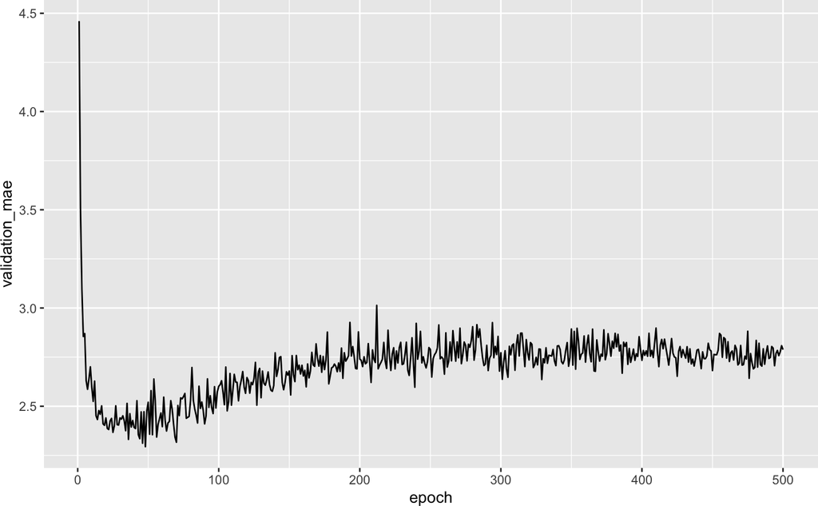

```r
library(ggplot2)
ggplot(average_mae_history, aes(x = epoch, y = validation_mae)) + geom_line()
```

It may be a bit hard to see the plot due to scaling issues and relatively high variance. Let’s use `geom_smooth()` to try to get a clearer picture:

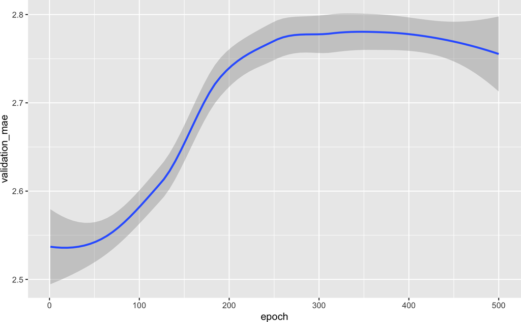

```r
ggplot(average_mae_history, aes(x = epoch, y = validation_mae)) + geom_smooth()
```

- It seems that validation MAE stops improving significantly after 70 epochs.
- Past that point, we start overfitting.

## 1.4 Final model at epoch 80

```r
# Get a fresh, compiled model.
model <- build_model()

# Train it on the entirety of the data.
model %>% fit(train_data, train_targets,
          epochs = 80, batch_size = 16, verbose = 0)

result <- model %>% evaluate(test_data, test_targets)
```

```r
result
```

```
     loss       mae
16.788279  2.649772
```

We are still off by about $\$$ 2649.77.